# Pandas/Jupyter Talk @ Amsterdam Python Meetup

> Author : Vincent D. Warmerdam @ GoDataDriven

This notebook and my talk will discuss

- how pandas can help you eliminate the bother out of simple data task
- how jupyter notebooks might change the way you write scripts
- what sugar both these tools have to offe

This notebook (and supplementary references) can be found on my blog: http://koaning.github.io "

# Why Notebook? Why Pandas?

[figure not shown]

Things you learn when working with data:

- data is domain specific
- I like to see what steps my colleague took
- I need things quick and flexible
- lots of steps are similar
- I like to apply the DRY principle
- I prefer typing to mouseclicking

Things that are nice about python:

- flexible language
- large community
- performance
- tends to written quickly

Things that are nice about jupyter notebooks:

- documentation is gratis!
- support for more than just python
- sugar for data analysis/quick scripting

Excel fails in many areas. Besides the fact that it cannot handle files larger than 1Gb the main problem with excel is...

[figure not shown]

### Documentation

Documentation is done via markdown in the actual notebook file. Tends to read better than comments in sublime and it makes it extremely easy to share with collegues. Notice that it also has support for formulas and other languages.

$$ a^2 + b^2 = c^2 $$

### The use of other languages:

```python
%%javascript
console.log("This is normal logged output")
console.log("%cDont make me angry. You wont like me when Im angry.","color: green; font-size:35px;font-weight: bold;")
```

By the way, did you know about this trick?

```python
%%javascript
console.log("moving kitten %c", "background: url('http://i.imgur.com/TanUtXo.gif'); padding-right: 300px; font-size: 250px; text-align: center")
```

```python
%%ruby
puts(1+1)
```

```
2
```

```python
%load_ext rmagic
```

```python
%%R
summary(ChickWeight)
```

```
     weight           Time           Chick     Diet
 Min.   : 35.0   Min.   : 0.00   13     : 12   1:220
 1st Qu.: 63.0   1st Qu.: 4.00   9      : 12   2:120
 Median :103.0   Median :10.00   20     : 12   3:120
 Mean   :121.8   Mean   :10.72   10     : 12   4:118
 3rd Qu.:163.8   3rd Qu.:16.00   17     : 12
 Max.   :373.0   Max.   :21.00   19     : 12
                                 (Other):506
```

### Package Management

You can install things via pip FROM the ipython notebook if you really wanted to.

```python
import pip

def install(package):
   pip.main(['install', package])

# install('pandas')
```

```python
import numpy as np
import pandas as pd
from ggplot import *
```

### Notebook Shortcuts

A list of some useful ones:

- ctrl + enter : run cell
- shift + enter : run cell and create/select the one after
- ctrl + m : enter command mode
- ctrl + s :save notebook While in command mode the shortcuts work a bit different:
- up/down arrows browser through different cells
- y : changes cell to a code cell
- m : changes cell to a markdown cell
- a : create new cell above
- b : create new cell below
- l : toggle line numbers
- dd : delete cell

# Pandas

[figure not shown]

Pandas gives you a datastructure called a DataFrame. This is the object that contains the data and methods that you'll use the most. Initially, the DataFrame will look like a dictionary that contains arrays with extra functionality but in real life it is an high performant data wrangler that provides a more flexible API than excel. Let's go and create a simple DataFrame.

```python
# first create three random arrays, the first two numeric, the last one string based
a = np.random.randn(10)
b = np.random.randn(10)
c = [ 'foo' if x > 0.5 else 'bar' for x in np.random.rand(10)]
d = { 'a' : pd.Series(a), 'b' : pd.Series(b), 'c': pd.Series(c) }
d
```

```
{'a': 0    0.527814
 1   -1.014339
 2   -0.116806
 3    0.650322
 4   -0.629597
 5    0.517408
 6   -0.472925
 7    0.332460
 8    1.011738
 9   -1.713077
 dtype: float64, 'b': 0   -1.461418
 1    0.597200
 2    1.059903
 3    1.932816
 4   -0.036146
```

[output cut: 16 more lines]

Note that difference between `a` and `pd.Series(a)`. Pandas translates arrays into a `pd.Series` object. These objects have characteristics that you would expect from an array but it allows for a flexible index. Normal arrays only have numerical indices but this object also allows for dates and strings. This also means that you can use said indices for more flexible selections of data.

[figure not shown]

> Source : https://www.youtube.com/watch?v=qbYYamU42Sw

Also note that pandas lists the `dtype` of the array, a normal python array will not do this. Pandas keeps track of what datatype is in the array, again to help you make selections. If the types aren't clear to pandas it will refer to it as an `object` array.

Let's now use this dictionary to create a DataFrame object.

```python
df = pd.DataFrame(d)
df
```

|  | a | b | c |
| --- | --- | --- | --- |
| 0 | 0.527814 | -1.461418 | foo |
| 1 | -1.014339 | 0.597200 | foo |
| 2 | -0.116806 | 1.059903 | foo |
| 3 | 0.650322 | 1.932816 | bar |
| 4 | -0.629597 | -0.036146 | bar |
| 5 | 0.517408 | 1.839549 | foo |
| 6 | -0.472925 | -1.766969 | foo |
| 7 | 0.332460 | 1.510172 | bar |
| 8 | 1.011738 | 0.831622 | foo |
| 9 | -1.713077 | 0.436959 | bar |

10 rows × 3 columns

This DataFrame object will be the main object you will talk to when using pandas. Note the column names are just like those assigned in the dictionary. Also note that the indices of this data frame at the same indices as the original `pd.Series` objects. This object should feel like the traditional excel table.

[figure not shown]

### List of simple queries we can ask to this object.

```python
# select a column from the dataframe, dict-style
df['a']
```

```
0    0.527814
1   -1.014339
2   -0.116806
3    0.650322
4   -0.629597
5    0.517408
6   -0.472925
7    0.332460
8    1.011738
9   -1.713077
Name: a, dtype: float64
```

```python
# so you can create a boolean list
df.a < 0
```

[output not shown]

```python
# this column behaves just like a numpy array
df['e'] = 1 + df.a
df
```

|  | a | b | c | e |
| --- | --- | --- | --- | --- |
| 0 | 0.527814 | -1.461418 | foo | 1.527814 |
| 1 | -1.014339 | 0.597200 | foo | -0.014339 |
| 2 | -0.116806 | 1.059903 | foo | 0.883194 |
| 3 | 0.650322 | 1.932816 | bar | 1.650322 |
| 4 | -0.629597 | -0.036146 | bar | 0.370403 |
| 5 | 0.517408 | 1.839549 | foo | 1.517408 |
| 6 | -0.472925 | -1.766969 | foo | 0.527075 |
| 7 | 0.332460 | 1.510172 | bar | 1.332460 |
| 8 | 1.011738 | 0.831622 | foo | 2.011738 |
| 9 | -1.713077 | 0.436959 | bar | -0.713077 |

10 rows × 4 columns

```python
# this true-false list can be used on the dataframe for selection
df[df.a < 0]
```

|  | a | b | c | e |
| --- | --- | --- | --- | --- |
| 1 | -1.014339 | 0.597200 | foo | -0.014339 |
| 2 | -0.116806 | 1.059903 | foo | 0.883194 |
| 4 | -0.629597 | -0.036146 | bar | 0.370403 |
| 6 | -0.472925 | -1.766969 | foo | 0.527075 |
| 9 | -1.713077 | 0.436959 | bar | -0.713077 |

5 rows × 4 columns

```python
# you can combine true false lists
df[ (df.a < 0) & (df.b < 0) ]
```

|  | a | b | c | e |
| --- | --- | --- | --- | --- |
| 4 | -0.629597 | -0.036146 | bar | 0.370403 |
| 6 | -0.472925 | -1.766969 | foo | 0.527075 |

2 rows × 4 columns

```python
# and we could again only get a certain column back
df[ (df.a < 0) & (df.b < 0) ].c
```

```
4    bar
6    foo
Name: c, dtype: object
```

Notice for this last query that we don't just get array values back. We also get the original indices from the dataframe.

```python
# we can also ask things directly to the DataFrame
df.head(1)
```

[output not shown]

```python
# what has a head, usually has a tail
df.tail(1)
```

[output not shown]

Note the indices for these two methods.

```python
# if you want to know the number of rows/columns
df.shape
```

[output not shown]

```python
# quick summary of data
df.describe()
```

[output not shown]

```python
# there are some basic functions you can use to aggregate
# axis = 0 indicates that we applying a function per column
df.mean(axis=0)
```

[output not shown]

```python
# there are some basic functions you can use to aggregate
# axis = 1 indicates that we applying a function per row
df.mean(axis=1)
```

[output not shown]

##### Small Historial Note

Pandas was written by Wes McKinney, who wrote it while working at a financial institution. Financial data analysis usually involves working a lot with dates. It is no coincidence that pandas has great support for working with time series. We can easily apply functions per week or per month.

The timeseries support is vast. Pandas only requires that the index of a dataframe is a timestamp. It then allows you to perform any function on any grouped part of data. So the index that is supplied doesn't have to be a number, it can also be a timestamp!

# Split-Apply-Combine

A moment of abstraction.

Whenever we are doing such an operation, we might look at it as a `split-apply-combine` operation, shown visually below:

[figure not shown]

Pandas has great support for these kinds of operations. Based on the key of a dataframe we will split the data and then apply functions to the grouped data.

# Enter ChickWeight

For this next bit we will use the chickweight dataset. This dataset contains information about different diets for chickens. The goal of the dataset is to find out which diet will get the chickens as fat as possible.

[figure not shown]

```python
chickdf = pd.read_csv('http://koaning.s3-website-us-west-2.amazonaws.com/data/pydata/chickweight.csv')
chickdf.describe()
```

|  | rownum | weight | Time | Chick | Diet |
| --- | --- | --- | --- | --- | --- |
| count | 578.000000 | 578.000000 | 578.000000 | 578.000000 | 578.000000 |
| mean | 289.500000 | 121.818339 | 10.717993 | 25.750865 | 2.235294 |
| std | 166.998503 | 71.071960 | 6.758400 | 14.568795 | 1.162678 |
| min | 1.000000 | 35.000000 | 0.000000 | 1.000000 | 1.000000 |
| 25% | 145.250000 | 63.000000 | 4.000000 | 13.000000 | 1.000000 |
| 50% | 289.500000 | 103.000000 | 10.000000 | 26.000000 | 2.000000 |
| 75% | 433.750000 | 163.750000 | 16.000000 | 38.000000 | 3.000000 |
| max | 578.000000 | 373.000000 | 21.000000 | 50.000000 | 4.000000 |

8 rows × 5 columns

Imagine doing just that operation in excel.

[figure not shown]

The goal is to find out which diet causes the most weight gain for chickens, so let's group chickens per diet. You do this by creating a grouped object. This groups the dataframe to groups based on column values. This `grouped` variable can be iterated over.

```python
grouped = chickdf.groupby(chickdf.Diet)

for thing in grouped:
    print thing
```

```
(1,         weight  Time  Chick  Diet
rownum
1           42     0      1     1
2           51     2      1     1
3           59     4      1     1
4           64     6      1     1
5           76     8      1     1
6           93    10      1     1
7          106    12      1     1
8          125    14      1     1
9          149    16      1     1
10         171    18      1     1
11         199    20      1     1
12         205    21      1     1
13          40     0      2     1
```

[output cut: 245 more lines]

Each group still behaves like a dataframe, so we can also apply the describe function here.

```python
grouped.describe()
```

| Diet |  | Chick | Time | weight |
| --- | --- | --- | --- | --- |
| 1 | count | 220.000000 | 220.000000 | 220.000000 |
|  | mean | 9.963636 | 10.481818 | 102.645455 |
|  | std | 5.700160 | 6.754984 | 56.656553 |
|  | min | 1.000000 | 0.000000 | 35.000000 |
|  | 25% | 5.000000 | 4.000000 | 57.750000 |
|  | 50% | 10.000000 | 10.000000 | 88.000000 |
|  | 75% | 14.000000 | 16.000000 | 136.500000 |
|  | max | 20.000000 | 21.000000 | 305.000000 |
| 2 | count | 120.000000 | 120.000000 | 120.000000 |
|  | mean | 25.500000 | 10.916667 | 122.616667 |
|  | std | 2.884324 | 6.804081 | 71.607495 |
|  | min | 21.000000 | 0.000000 | 39.000000 |
|  | 25% | 23.000000 | 5.500000 | 65.500000 |
|  | 50% | 25.500000 | 11.000000 | 104.500000 |
|  | 75% | 28.000000 | 16.500000 | 163.000000 |
|  | max | 30.000000 | 21.000000 | 331.000000 |
| 3 | count | 120.000000 | 120.000000 | 120.000000 |
|  | mean | 35.500000 | 10.916667 | 142.950000 |
|  | std | 2.884324 | 6.804081 | 86.541761 |
|  | min | 31.000000 | 0.000000 | 39.000000 |
|  | 25% | 33.000000 | 5.500000 | 67.500000 |
|  | 50% | 35.500000 | 11.000000 | 125.500000 |
|  | 75% | 38.000000 | 16.500000 | 198.750000 |
|  | max | 40.000000 | 21.000000 | 373.000000 |
| 4 | count | 118.000000 | 118.000000 | 118.000000 |
|  | mean | 45.525424 | 10.754237 | 135.262712 |
|  | std | 2.902141 | 6.744338 | 68.828714 |
|  | min | 41.000000 | 0.000000 | 39.000000 |
|  | 25% | 43.000000 | 4.500000 | 71.250000 |
|  | 50% | 46.000000 | 10.000000 | 129.500000 |
|  | 75% | 48.000000 | 16.000000 | 184.750000 |
|  | max | 50.000000 | 21.000000 | 322.000000 |

### Applying your own

We can use built in functions on our grouped objects, but we can also just apply our own functions. Note that these functions need to be able to be applied to a DataFrame object.

```python
def show_size(x):
    return "Dude we have " + str(len(x)) + " chickens here!"

grouped.apply(show_size)
```

```
Diet
1       Dude we have 220 chickens here!
2       Dude we have 120 chickens here!
3       Dude we have 120 chickens here!
4       Dude we have 118 chickens here!
dtype: object
```

Realize that this means that **any** function can be used here. You will want to think about performance when dealing with large datasets. This functionality is one of the things that make the pandas API very powerful.

[figure not shown]

### Advanced Groups

We can also created groups based on two columns in the table.

```python
chickdf.groupby(['Diet','Time']).weight.apply(show_size)
```

```
Diet  Time
1     0       Dude we have 20 chickens here!
      2       Dude we have 20 chickens here!
      4       Dude we have 19 chickens here!
      6       Dude we have 19 chickens here!
      8       Dude we have 19 chickens here!
      10      Dude we have 19 chickens here!
      12      Dude we have 19 chickens here!
      14      Dude we have 18 chickens here!
      16      Dude we have 17 chickens here!
      18      Dude we have 17 chickens here!
      20      Dude we have 17 chickens here!
      21      Dude we have 16 chickens here!
2     0       Dude we have 10 chickens here!
      2       Dude we have 10 chickens here!
```

[output cut: 35 more lines]

[figure not shown]

# Visualisation

You can also combine pandas with plotting tools like **ggplot** for fast interactive data exploration.

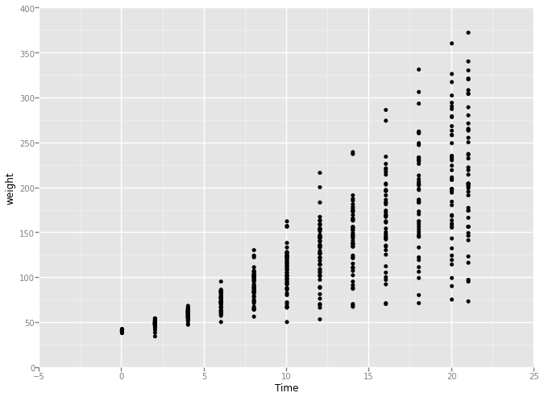

```python
%pylab inline

ggplot(aes(x='Time', y='weight'), data=chickdf) + geom_point()
```

```python
agg = chickdf.groupby(['Diet','Time']).weight.aggregate(mean)
agg = agg.reset_index()
agg
```

|  | Diet | Time | weight |
| --- | --- | --- | --- |
| 0 | 1 | 0 | 41.400000 |
| 1 | 1 | 2 | 47.250000 |
| 2 | 1 | 4 | 56.473684 |
| 3 | 1 | 6 | 66.789474 |
| 4 | 1 | 8 | 79.684211 |
| 5 | 1 | 10 | 93.052632 |
| 6 | 1 | 12 | 108.526316 |
| 7 | 1 | 14 | 123.388889 |
| 8 | 1 | 16 | 144.647059 |
| 9 | 1 | 18 | 158.941176 |
| 10 | 1 | 20 | 170.411765 |
| 11 | 1 | 21 | 177.750000 |
| 12 | 2 | 0 | 40.700000 |
| 13 | 2 | 2 | 49.400000 |
| 14 | 2 | 4 | 59.800000 |
| 15 | 2 | 6 | 75.400000 |
| 16 | 2 | 8 | 91.700000 |
| 17 | 2 | 10 | 108.500000 |
| 18 | 2 | 12 | 131.300000 |
| 19 | 2 | 14 | 141.900000 |
| 20 | 2 | 16 | 164.700000 |
| 21 | 2 | 18 | 187.700000 |
| 22 | 2 | 20 | 205.600000 |
| 23 | 2 | 21 | 214.700000 |
| 24 | 3 | 0 | 40.800000 |
| 25 | 3 | 2 | 50.400000 |
| 26 | 3 | 4 | 62.200000 |
| 27 | 3 | 6 | 77.900000 |
| 28 | 3 | 8 | 98.400000 |
| 29 | 3 | 10 | 117.100000 |
| 30 | 3 | 12 | 144.400000 |
| 31 | 3 | 14 | 164.500000 |
| 32 | 3 | 16 | 197.400000 |
| 33 | 3 | 18 | 233.100000 |
| 34 | 3 | 20 | 258.900000 |
| 35 | 3 | 21 | 270.300000 |
| 36 | 4 | 0 | 41.000000 |
| 37 | 4 | 2 | 51.800000 |
| 38 | 4 | 4 | 64.500000 |
| 39 | 4 | 6 | 83.900000 |
| 40 | 4 | 8 | 105.600000 |
| 41 | 4 | 10 | 126.000000 |
| 42 | 4 | 12 | 151.400000 |
| 43 | 4 | 14 | 161.800000 |
| 44 | 4 | 16 | 182.000000 |
| 45 | 4 | 18 | 202.900000 |
| 46 | 4 | 20 | 233.888889 |
| 47 | 4 | 21 | 238.555556 |

48 rows × 3 columns

[figure not shown]

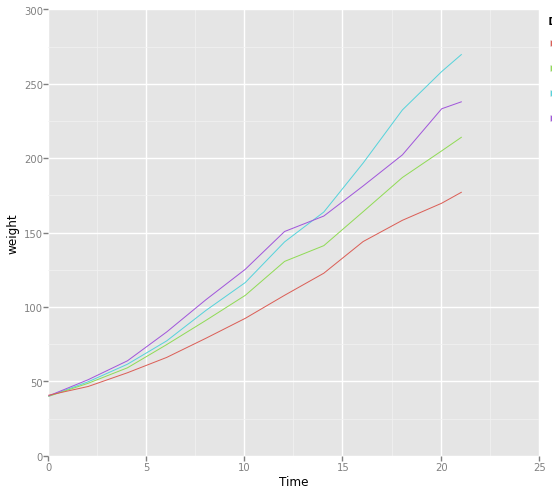

```python
ggplot(aes(x='Time', y='weight', color="Diet"), data=agg) + geom_line()
```

But in all seriousness, you might want to start thinking about the ethics used in data.

### More Resources

- (my blog) http://koaning.github.io
- http://jupyter.org/
- http://pandas.pydata.org/
- http://ggplot.yhathq.com/